# **菊安酱与菜菜的Python机器学习可视化**

### 4.绘制时间序列图

```python
df.head()
```

|  | date | value |
| --- | --- | --- |
| 0 | 1949-01-01 | 112 |
| 1 | 1949-02-01 | 118 |
| 2 | 1949-03-01 | 132 |
| 3 | 1949-04-01 | 129 |
| 4 | 1949-05-01 | 121 |

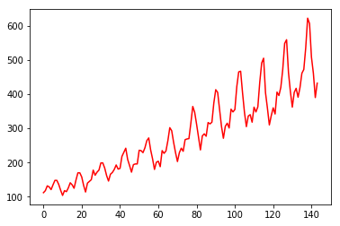

```python
#绘制时间序列折线图
plt.plot(df.value,color='r');
```

其实，时间序列图非常的简单，我们一行代码基本上就把图形画出来了……

接下来，我们再稍微修饰一下图形

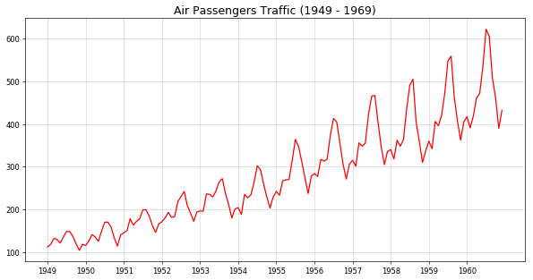

```python
#创建画布并设定画布大小
plt.figure(figsize=(12,6),dpi=60)

#绘制折线图
plt.plot(df.value,color='r')

#添加装饰
plt.title('Air Passengers Traffic (1949 - 1969)',fontsize=15)
plt.xticks(range(df.shape[0])[::12],df.date.dt.year[::12])
plt.grid(alpha=.5);
```

到这里，仅仅用了5行代码，我们就把时间序列图画出来啦~~~~  
但是！！！请看下面的源代码……

```python
# Import Data
df = pd.read_csv('https://github.com/selva86/datasets/raw/master/AirPassengers.csv')

# Draw Plot
plt.figure(figsize=(16,10), dpi= 80)
plt.plot('date', 'traffic', data=df, color='tab:red')

# Decoration
plt.ylim(50, 750)
xtick_location = df.index.tolist()[::12]
xtick_labels = [x[-4:] for x in df.date.tolist()[::12]]
plt.xticks(ticks=xtick_location, labels=xtick_labels, rotation=0, fontsize=12, horizontalalignment='center', alpha=.7)
plt.yticks(fontsize=12, alpha=.7)
plt.title("Air Passengers Traffic (1949 - 1969)", fontsize=22)
plt.grid(axis='both', alpha=.3)

# Remove borders
plt.gca().spines["top"].set_alpha(0.0)
plt.gca().spines["bottom"].set_alpha(0.3)
plt.gca().spines["right"].set_alpha(0.0)
plt.gca().spines["left"].set_alpha(0.3)
plt.show()
```

### 源代码竟然有这么长，宝宝表示很震惊…………

[figure not shown]

源代码中有两处错误，这里已经修正：  
（1）df数据集中列名分别为date/value,没有traffic  
（2）关于x轴刻度，如果想要保留字符串前4位作为年份，应该是x[:4],而不是[-4:]

下面我们一起来看一下源代码是如何画时间序列图的~

```python
#源代码(修正版)

# Import Data
df = pd.read_csv('https://github.com/selva86/datasets/raw/master/AirPassengers.csv') #导入数据集
```

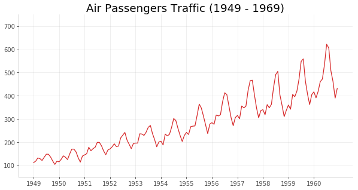

```python
# Draw Plot
plt.figure(figsize=(12,6), dpi= 60) #创建画布并设定画布大小
plt.plot('date', 'value', data=df, color='tab:red') #绘制折线图

# Decoration
plt.ylim(50, 750)   #设定y轴刻度范围
xtick_location = df.index.tolist()[::12]  #每12个索引提取一个
xtick_labels = [x[:4] for x in df.date.tolist()[::12]] #df日期列每12个提取一个
plt.xticks(ticks=xtick_location, labels=xtick_labels #人为将x轴刻度稀疏化，并且设定年份作为刻度标签
           ,rotation=0   #rotation指的是刻度标签旋转的角度，默认为 0度
           ,fontsize=12  #设定刻度字体大小
           ,horizontalalignment='center' #设定水平对齐方式，可选项为left/right/center,默认为center
           ,alpha=.7     #设定刻度标签的透明度，默认为1（此参数并不会改变轴的透明度）
          )

plt.yticks(fontsize=12, alpha=.7) #设定y轴刻度标签大小和透明度
plt.title("Air Passengers Traffic (1949 - 1969)", fontsize=22) #添加图标标题
plt.grid(axis='both', alpha=.3) #配置网格线，并设定网格线透明度,axis的可选项有x/y/both(默认为both)

# Remove borders
plt.gca().spines["top"].set_alpha(0.0)    #获取当前子图，并设定上边框透明度为0,相当于去掉了上边框
plt.gca().spines["bottom"].set_alpha(0.3) #弱化下边框的颜色
plt.gca().spines["right"].set_alpha(0.0)  #去掉右边框
plt.gca().spines["left"].set_alpha(0.3)   #弱化左边框的颜色
plt.show()  #本地显示图形，可用分号;代替
```

#### ※绘制折线图的另一种设定方式

将全部数据赋值给data参数，然后从中挑选出绘图所需的数据

```python
m = pd.DataFrame({'m':np.arange(2,21,2),'n':np.random.rand(10),'l':np.random.randn(10)})
```

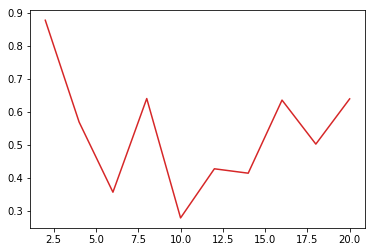

```python
plt.plot('m', 'n', data=m, color='tab:red');

#tab:red——是“T10”分类调色板中的Tableau颜色
#共10种：{'tab:blue', 'tab:orange', 'tab:green', 'tab:red', 'tab:purple',
#'tab:brown', 'tab:pink', 'tab:gray', 'tab:olive', 'tab:cyan'}
```

这里的color设定参考Matplotlib官网说明：https://matplotlib.org/users/colors.html

### 5. 图像解读

- 从1949年到1960年该航空公司的乘客人数逐年上涨
- 每年的乘客人数呈现出了季节性趋势：年中出现高峰